# Hospitality

## Plotting pie chart

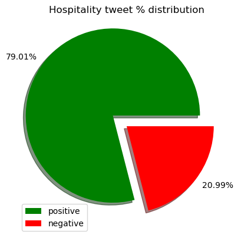

```python
import pandas as pd
import matplotlib.pyplot as plt
data=pd.read_csv("D:\\Internship Progress\\WEEK3 new updated\\WEEK3\\Hospitality\\hospitality_1.csv")
count_positive = 0
count_negative = 0
count_neutral = 0

for sentiment in data['sentiment']:
    if sentiment == 'Positive':
        count_positive += 1
    else:
        count_negative += 1
total=len(data)
positive_response= (count_positive / total) * 100
negative_response = (count_negative / total) * 100
myexplode = [0.2, 0]
y=[positive_response,negative_response]
plt.pie(y,labels=[str(round(positive_response,2))+"%",str(round(negative_response,2))+"%"],explode = myexplode, shadow = True,colors=["g","r"])
plt.title("Hospitality tweet % distribution")
plt.legend(["positive","negative"])
plt.show()
```

# LDA for positive tweets

```python
import pandas as pd
from sklearn.feature_extraction.text import CountVectorizer
from sklearn.decomposition import LatentDirichletAllocation

from sklearn.feature_extraction import text

# Read the positive reviews data
positive_reviews = pd.read_csv("D:\\Internship Progress\\WEEK3 new updated\\WEEK3\\Hospitality\\hospitality_1 - Copy.csv")

# Combine reviews into a list
reviews = positive_reviews['tweet'].tolist()

# Create a custom stop words list if needed
custom_stop_words = ["read", "good", "disney", "yorker", "day", "didn", "stay", "great", "check", "booked", "like", "die", "told", "friendly", "clean", "sehr", "das", "zimmer", "und", "nice", "did", "was", "really", "safe", "walk", "close", "got"]

# Add your custom stop words to this list
stop_words = text.ENGLISH_STOP_WORDS.union(custom_stop_words)

# Vectorize the text data
vectorizer = CountVectorizer(max_df=0.95, min_df=2, stop_words=stop_words)
X = vectorizer.fit_transform(reviews)

# Apply LDA for topic modeling
num_topics = 5
lda = LatentDirichletAllocation(n_components=num_topics, random_state=42)
lda.fit(X)

# Extract top words for each topic
feature_names = vectorizer.get_feature_names_out()
topics = []
for topic_idx, topic in enumerate(lda.components_):
    top_words_idx = topic.argsort()[-10:]
    top_words = [feature_names[i] for i in top_words_idx]
    topics.append(top_words)

# Print the top words for each topic (possible reasons for positive reviews)


for i, topic in enumerate(topics):
    print(f"Topic {i + 1}: {', '.join(topic)}")
```

```
Topic 1: travel, comfort, near, relax, exceptional, warm, experience, best, hotel, bangalore
Topic 2: staff, thanks, beautiful, enjoying, dr, meet, 6e, indigo, amp, bangalore
Topic 3: enjoyed, today, say, launch, kind, food, thank, lounge, service, bangalore
Topic 4: wonderful, mr, flight, india, experience, best, road, staff, lounge, bangalore
Topic 5: girl, polite, bengaluru, wonderful, journey, swissness, team, thanks, service, bangalore
```

# Observation on positive tweet

- ### Travel and hotels: The tweeters had exceptional experiences traveling to and staying in Bangalore, with comfortable accommodations and warm hospitality.
- ### Staff and service: The tweeters were impressed by the friendly and helpful staff in Bangalore, both at the airport and in the hotel lounge.
- ### Food and drink: The tweeters enjoyed the delicious food and drinks in Bangalore, especially at the hotel lounge.
- ### Overall experience: The tweeters had a wonderful overall experience in Bangalore, finding the city to be beautiful, vibrant, and welcoming. ## Recommendations:
- ### Partner with travel agencies and tour operators to create packages that showcase the best of Bangalore, including its culture, cuisine, and attractions.
- ### Work with hotels and restaurants to offer discounts and promotions to visitors.
- ### Invest in public transportation and infrastructure to make it easier for visitors to get around the city.
- ### Develop a comprehensive tourism website and mobile app that provides visitors with information on all aspects of Bangalore, including attractions, transportation, dining, and shopping.
- ### Promote Bangalore on social media and other online platforms to reach a wider audience of potential visitors.
- ### By following these recommendations, Bangalore can continue to attract visitors from all over the world and maintain its reputation as a world-class city.